# Modelos (Descriptiva, BIOCLIM, MAXENT, GLM, BRT & RF)

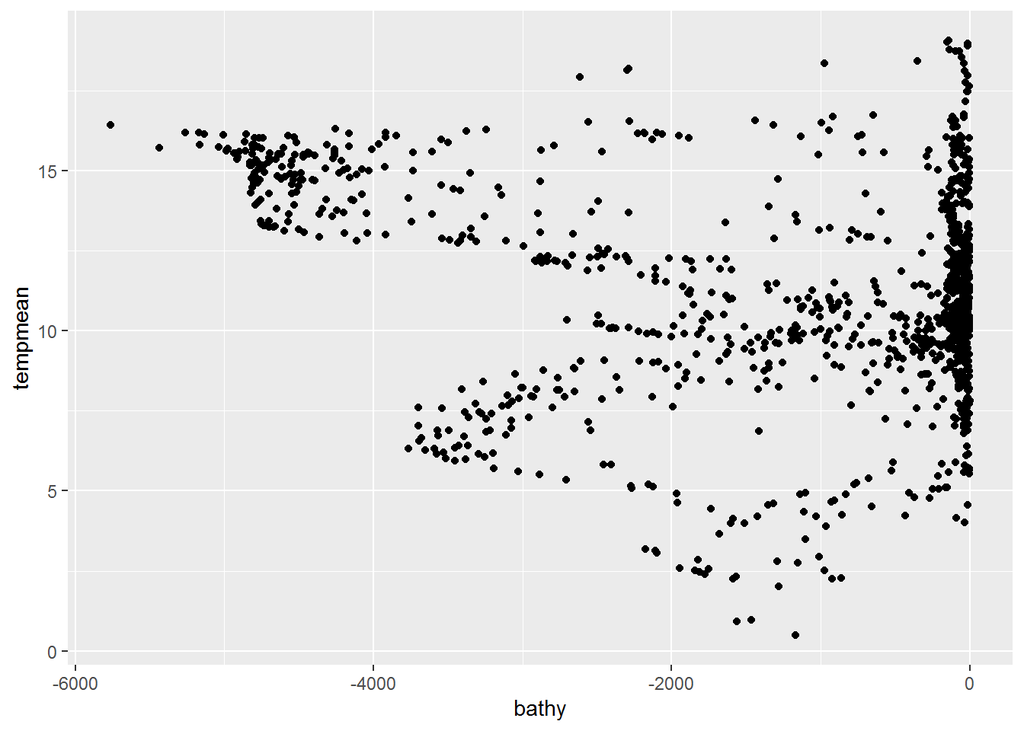

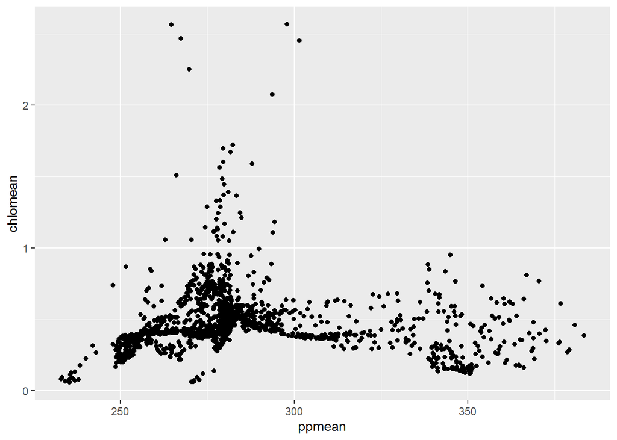

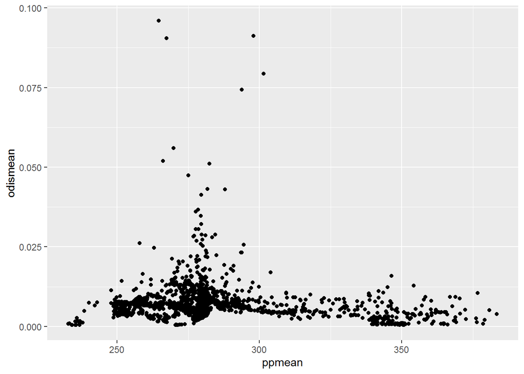

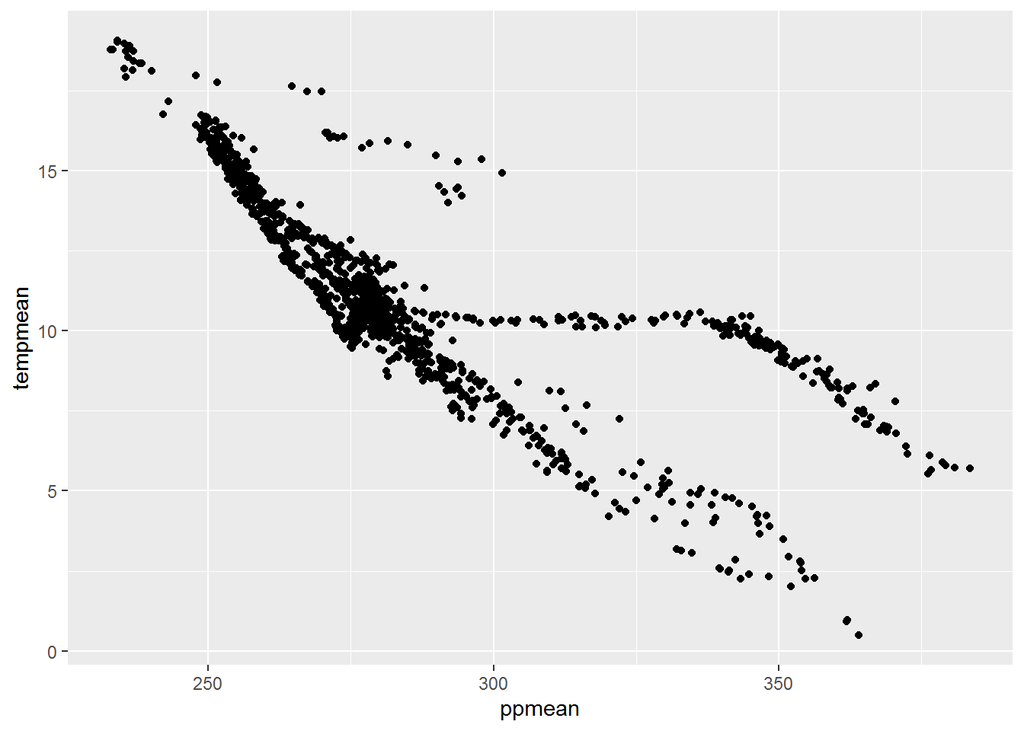

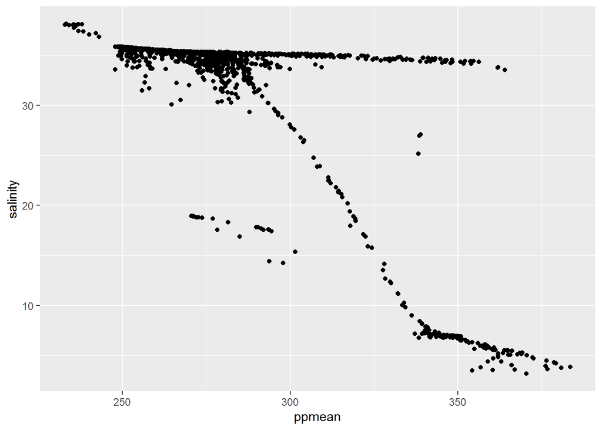

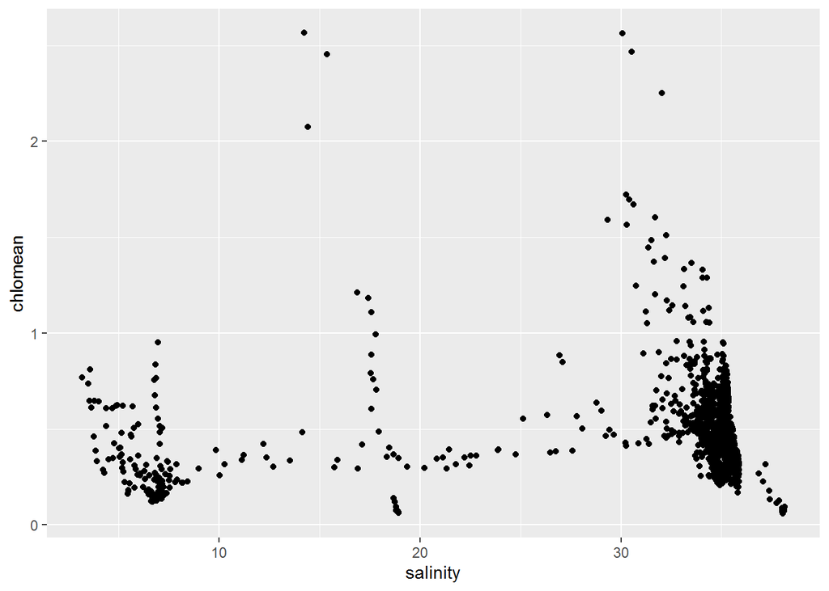

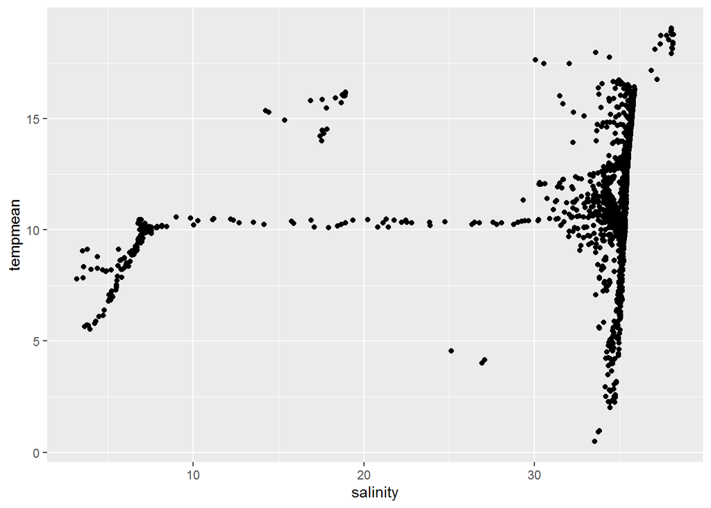

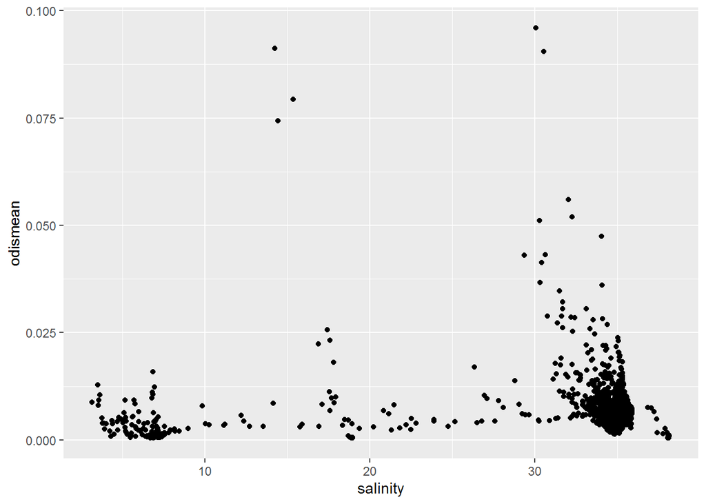

[3 more figures not shown]

Al comparar las gráficas en las que se relacionan las variables escaladas y no se comprueba que efectivamente entre ellas tienen una relación un poco extraña.

Estas relaciones entre las covariables sirve de aliciente para pensar que uno de los modelos a realizar sea un modelo aditivo generalizado (GAM). Además, cabe mencionar que la variable respuesta se distribuye como una binomial por lo que otro de los modelos a plantear será un modelo lineal generalizado (GLM).

En la linea de selección de variables, a continuación se mirará la multicolinealidad entre ellas mediante el VIF (factor de inflación de la varianza). Para ello se partirá de todas las variables y posteriormente se irán eliminando una a una las que tengan un mayor valor hasta que el grupo quede con valores de VIF menores a 3.

```r
# Compruebo si hay o no multicolinealidad entre variables
# El objetivo es quedarse con un conjunto de variables con un VIF menor a 5 y 3.

source("HighstatLib.r") #Función ya hecha
# corvif(sdmdata[,c(3:8)]) #Solo la hago para las que no son covaraibles

corvif(sdmdata[,c(3,6,7,8)]) #He ido quitando una a una las que tenían un GVIF mas alto, ppmean y chlmean
```

```
  Correlations of the variables

                bathy  odismean   salinity   tempmean
  bathy     1.0000000 0.1258865 -0.2850204 -0.2580218
  odismean  0.1258865 1.0000000  0.1201819  0.1225897
  salinity -0.2850204 0.1201819  1.0000000  0.2234797
  tempmean -0.2580218 0.1225897  0.2234797  1.0000000


  Variance inflation factors

               GVIF
  bathy    1.182147
  odismean 1.064776
  salinity 1.140601
  tempmean 1.121811
```

Las variables con las que me quedaré finalmente han sido: batimetría, oxígeno disuelto, temperatura media y salinidad.

```r
# Creo una variable predictores que solo incluya a esas cuatro
# Solo uso las covariables seleccionadas

cuatro_pred <- (list.files("C:/Users/Irene/Source/Repositorios/TFM-Irene-Extremera/Predictores/atl/Seleccionadas", full.names=T, pattern=".tif")) #Cargo bathy que lo he metido en una carpeta aparte
predictors <- stack(cuatro_pred)
names(predictors) <- c("bathy","odismean","salinity","tempmean")
predictors3 <- scale(predictors)

# Elimino esas covariables de la base de datos

sdmdata <- sdmdata[,c(-1,-4,-5)]
```

##### — Ajuste modelos —

El esquema que voy a intentar seguir en los modelos va a ser el siguiente:

- Ajuste
- Valoración del modelo usando los residuos (Si puede hacerse)
- Predictiva
- Plot
- Validación cruzada
- Índice de Moran para ver si puede meterse la componente espacial

##### — BIOCLIM —

Primero comenzaré con el modelo mas sencillo, bioclim del paquete dismo.

```r
# Hago el modelo de BIOCLIM

bc.model <- bioclim(x = predictors3, p = data)
bc.model
```

```
  class    : Bioclim

  variables: bathy odismean salinity tempmean


  presence points: 451
           bathy  odismean    salinity tempmean
  1   0.45716806 -1.255609  0.35647978 1.864047
  2   0.23255513 -1.239536  0.40341195 1.792199
  3   0.80088409 -1.182861  0.41954352 1.590200
  5   0.80217869 -1.221671  0.31535739 1.837500
  7   0.81383008 -1.175265  0.24265450 1.810521
  8   0.28174989 -1.233232  0.35108793 1.844675
  9   0.87338164 -1.033680 -0.04763055 1.652511
  10  0.82030308 -1.121639  0.21673499 1.759532
  11 -0.05678775 -1.174639  0.34473452 1.813785
  12  0.26556740 -1.173120  0.41469042 1.725042
    (... ...  ...)
```

```r
# Guardo el modelo

saveRDS(bc.model, "C:/Users/Irene/Source/Repositorios/TFM-Irene-Extremera/BIOCLIM/bc.model.rds") #Guardo el modelo BIOCLIM
```

Dentro del objeto no hay residuos por lo que no puedo hacer ningún tipo de análisis de los residuos. Por lo que paso directamente a la realización y representación de la predictiva.

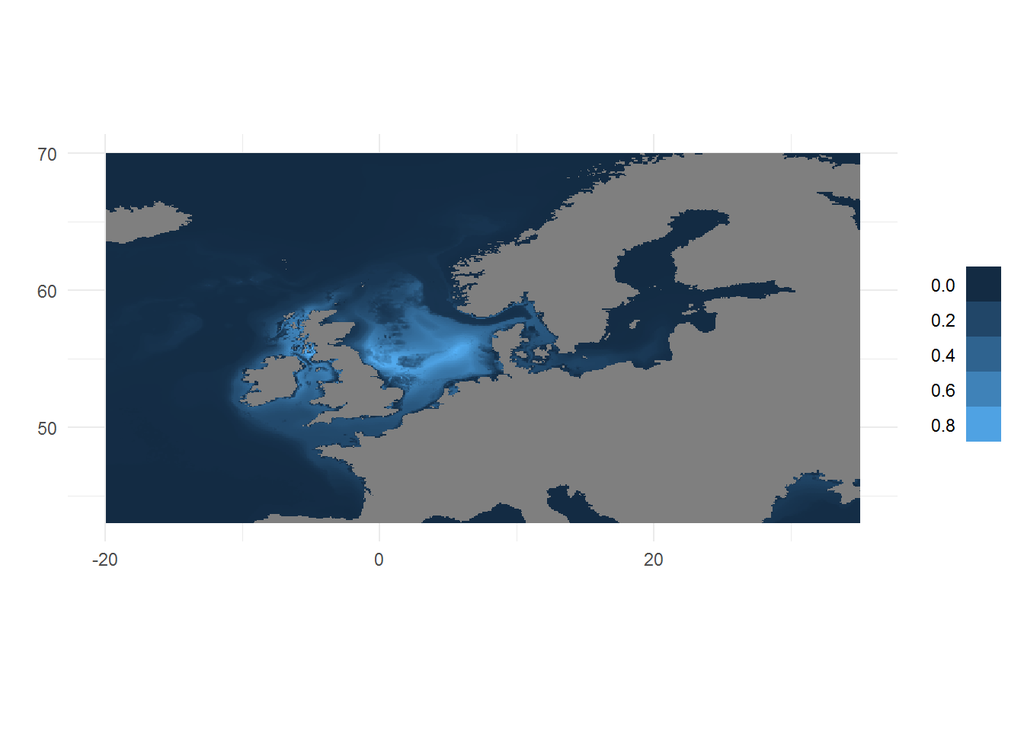

```r
# Predictiva de presencias
ext <-extent(-20,35,43,70) #Para Atlántico Norte

predict_presence_bc_bioclim <- predict(object = bc.model,
                                   x = predictors3,
                                   ext = ext)

# La pinto
ggplot() +
  geom_raster(data = raster::as.data.frame(predict_presence_bc_bioclim , xy = TRUE) , aes(x = x, y = y, fill = layer)) +
  coord_equal() +
  labs( x = "", y = "")+theme_minimal()+
  scale_color_brewer(palette = 'YlGnBu')+ labs(fill='') +
  guides(fill = guide_legend(label.position = "left", label.hjust = 1))
```

```r
# La guardo
saveRDS(predict_presence_bc_bioclim, "C:/Users/Irene/Source/Repositorios/TFM-Irene-Extremera/BIOCLIM/Predicciones_BIOCLIM_Atl.ascii")
```

En el mapa predictivo se puede ver que en el Mar del Norte y en la parte de costa Oeste de Gran Bretaña y Francia hay una probabilidad de presencia de hasta el 0.8. Este valor va disminuyendo progresivamente a medida que se aleja de la zona.

A continuación valoro la calidad predictiva del modelo mediante la media de diez validaciones cruzadas.

```r
# FUNCIÓN DEFINITIVA DEFINITIVÍSIMA MILENARIA XTREM para BIOCLIM.
# Esta función sirve para hacer una cross validation y obtener así los distintos índices que me interesan.

fddmx <- function(coordenadas, predictores,background){

      group <- kfold(coordenadas, 5)

      pres_train <- coordenadas[group != 1, ] #Las que no sean 1
      pres_test <- coordenadas[group == 1, ] #Las que sean 1

      bc <- bioclim(predictores, pres_train)

      group <- kfold(background, 5) #Hago 5 grupos de esos puntos
      backg_train <- background[group != 1, ]
      backg_test <- background[group == 1, ]

      eval.modesta <- evaluate(pres_test, backg_test, bc, predictores)

      auc_model <- eval.modesta@auc #auc

      cor_model <- eval.modesta@cor #cor

      kappa_model <- mean(eval.modesta@kappa) #Kappa

      sensibility_model <- mean(eval.modesta@TPR/(eval.modesta@TPR+eval.modesta@FNR)) #Sensibilidad

      specificity_modelo <- mean(eval.modesta@TNR/(eval.modesta@FPR+eval.modesta@TNR)) #Especificidad

      TSS_model <- mean(eval.modesta@TPR+eval.modesta@TNR-1) #TSS

      return(c(auc_model,cor_model,kappa_model,sensibility_model,specificity_modelo,TSS_model))
}

# Hago una matriz para guardar los valores de los coeficientes de las diez iteraciones que me devuelva la función
cosites_bc_model <- matrix(ncol=6,nrow=10)

# Genereo un bucle for de 10 iteraciones que me devuelva 10 valores diferentes de los 6 coeficientes.
for (i in 1:10) { cosites_bc_model[i,] <- fddmx(data,predictors3,backgr)}

# Le doy nombre a las columnas para saber qué coeficientes hay dentro
colnames(cosites_bc_model) <- c('AUC','COR','Kappa','Sensitivity','Specificity','TSS')

# Hago la media por columnas que es lo que me interesa y lo guardo
coef_bc_model <- apply(cosites_bc_model, 2, mean)
write.csv(coef_bc_model,'C:/Users/Irene/Source/Repositorios/TFM-Irene-Extremera/BIOCLIM/coeficientes_BIOCLIM.csv')#Guardo los coeficientes
coef_bc_model
```

```
          AUC         COR       Kappa Sensitivity Specificity         TSS
    0.8565058   0.5242248   0.3550467   0.4894779   0.8612979   0.3507758
```

Como el modelo de bioclim del paquete dismo no da residuos no puedo utilizarlos para valorar si existe correlación espacial usando el índice de Moran.

Por lo que esto es todo lo que podría realizarse con este modelo (?)

##### — MAXENT —

El siguiente modelo a realizar será MAXENT, que es muy sencillo de realizar computacionalmente pero es difícil de interpretar en cuanto a lo que hace por dentro (caja negra).

```r
# Construyo el modelo

maxent_model <- maxent(predictors3, data,backgr)
```

```
  This is MaxEnt version 3.3.3k
```

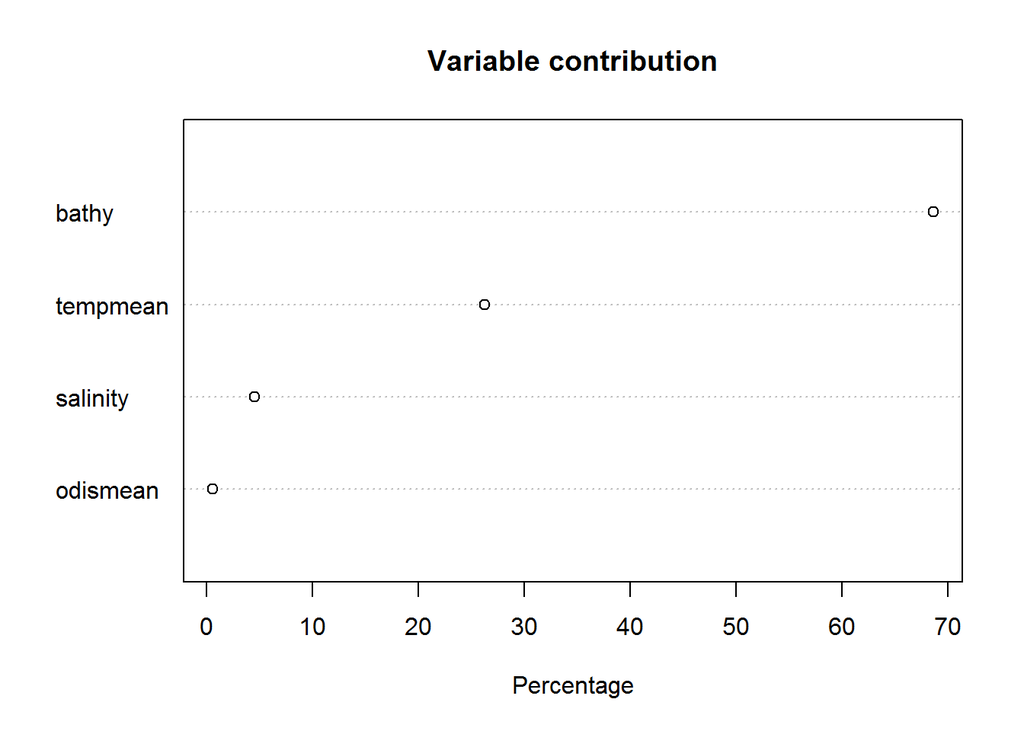

```r
saveRDS(maxent_model, "C:/Users/Irene/Source/Repositorios/TFM-Irene-Extremera/MAXENT/maxent_model_atl.rds")

plot(maxent_model)
```

Como el modelo MAXENT del paquete dismo no da tampoco los residuos, no puedo hacer un análisis de los mismo, por lo que pasaré a la realización de la predicción.

```r
# Predicciones de presencia

predict_presence_maxent_model <- dismo::predict(object = maxent_model,
                                   x = predictors3,
                                   ext = ext)
```

```
  This is MaxEnt version 3.3.3k
```

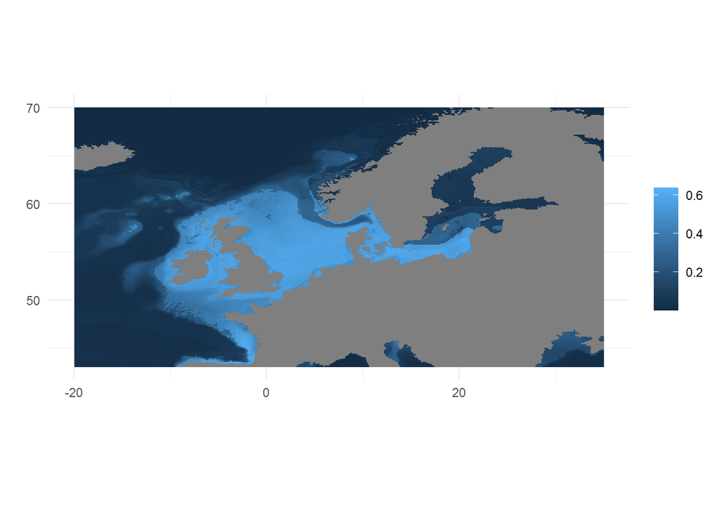

```r
# La pinto
ggplot() +
  geom_raster(data = raster::as.data.frame(predict_presence_maxent_model , xy = TRUE) , aes(x = x, y = y, fill = layer)) +
  coord_equal() +
  labs( x = "", y = "")+theme_minimal()+
  scale_color_brewer(palette = 'YlGnBu')+ labs(fill='')+

# Me guardo el modelo predictivo
saveRDS(predict_presence_maxent_model, "C:/Users/Irene/Source/Repositorios/TFM-Irene-Extremera/MAXENT/Predicciones_MAXENT_alt.ascii")
```

```r
fddmx1 <- function(coordenadas, predictores,background){

      group <- kfold(coordenadas, 5)

      pres_train <- coordenadas[group != 1, ] #Las que no sean 1
      pres_test <- coordenadas[group == 1, ] #Las que sean 1

      me_m<- maxent(predictores, pres_train,background)

      group <- kfold(background, 5) #Hago 5 grupos de esos puntos
      backg_train <- background[group != 1, ]
      backg_test <- background[group == 1, ]

      eval.modesta <- evaluate(pres_test, backg_test, me_m, predictores)

      auc_model <- eval.modesta@auc #auc

      cor_model <- eval.modesta@cor #cor

      kappa_model <- mean(eval.modesta@kappa) #Kappa

      sensibility_model <- mean(eval.modesta@TPR/(eval.modesta@TPR+eval.modesta@FNR)) #Sensibilidad

      specificity_modelo <- mean(eval.modesta@TNR/(eval.modesta@FPR+eval.modesta@TNR)) #Especificidad

      TSS_model <- mean(eval.modesta@TPR+eval.modesta@TNR-1) #TSS

      return(c(auc_model,cor_model,kappa_model,sensibility_model,specificity_modelo,TSS_model))
}

# Hago una matriz para guardar los valores de los coeficientes de las diez iteraciones que me devuelva la función
cosites_maxent_model <- matrix(ncol=6,nrow=10)

# Genereo un bucle for de 10 iteraciones que me devuelva 10 valores diferentes de los 6 coeficientes.
for (i in 1:10) { cosites_maxent_model[i,] <- fddmx1(data,predictors3,backgr)}
```

[output not shown]

```r
# Le doy nombre a las columnas para saber qué coeficientes hay dentro
colnames(cosites_maxent_model) <- c('AUC','COR','Kappa','Sensitivity','Specificity','TSS')


# Hago la media por columnas que es lo que me interesa y lo guardo
coef_mx_model <- apply(cosites_maxent_model, 2, mean)
coef_mx_model
```

```
          AUC         COR       Kappa Sensitivity Specificity         TSS
    0.9021330   0.6838502   0.3589491   0.7728493   0.6243651   0.3972144
```

```r
write.csv(coef_mx_model,'C:/Users/Irene/Source/Repositorios/TFM-Irene-Extremera/MAXENT/coeficientes_MAXENT_atln.csv')
```

Al igual que el anterior, al no disponer de los residuos no se puede ver si hay correlación espacial entre las observaciones usando el índice de Moran.